# psrwe: Propensity Score-Integrated Methods for Incorporating Real-World Evidence in Clinical Studies

Chenguang Wang

2022-02-28

[output not shown]

[output not shown]

# Introduction

In the *R* package **psrwe**, we implement a series of approaches for leveraging real-world evidence in clinical study design and analysis.

# Propensity score estimation

```r
data(ex_dta)
dta_ps <- psrwe_est(ex_dta,
                     v_covs = paste("V", 1:7, sep = ""),
                     v_grp = "Group",
                     cur_grp_level = "current",
                     nstrata = 5,
                     ps_method = "logistic")
dta_ps
```

```
## This is a sing-arm study. A total of 1031 RWD subjects and
## 200 current study subjects are used to estimate propensity
## scores by logistic model. A total of 5 RWD subjects are
## trimmed and excluded from the final analysis. The following
## covariates are adjusted in the propensity score model: V1,
## V2, V3, V4, V5, V6, V7.
##
## The following table summarizes the number of subjects in
## each stratum, and the distance in PS distributions
## calculated by overlapping area:
##
##     Stratum N_RWD N_Current  Distance
## 1 Stratum 1   729        40 0.5613996
## 2 Stratum 2   156        40 0.7208211
## 3 Stratum 3    78        40 0.8042718
## 4 Stratum 4    50        40 0.8104474
## 5 Stratum 5    13        40 0.7960132
```

It is extremely important to evaluate the propensity score adjustment results. In **psrwe**, functions are provided to visualize the balance in covariate distributions and propensity score distributions based on propensity score stratification.

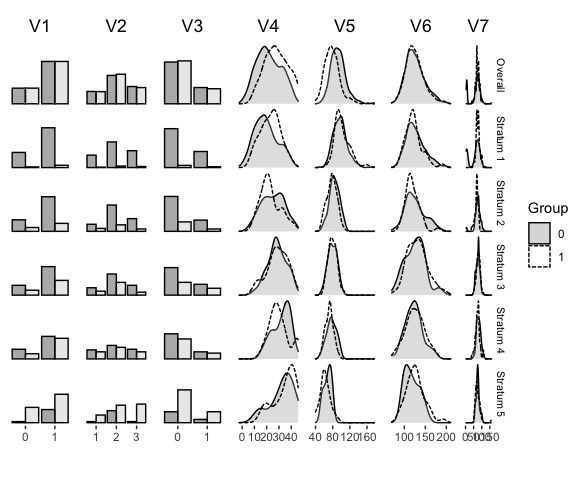

```r
plot(dta_ps, plot_type = "balance")
```

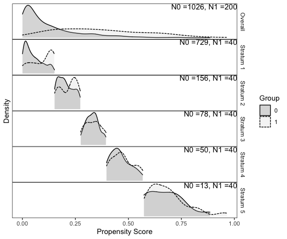

```r
plot(dta_ps, plot_type = "ps")
```

# PS-integrated power prior approach for single arm studies

For single arm studies when there is one external data source, the function **psrwe_powerp** allows one to conduct the analysis proposed in Wang et. al. (2019). The method uses propensity score to pre-select a subset of real-world data containing patients that are similar to those in the current study in terms of covariates, and to stratify the selected patients together with those in the current study into more homogeneous strata. The power prior approach is then applied in each stratum to obtain stratum-specific posterior distributions, which are combined to complete the Bayesian inference for the parameters of interest.

```r
ps_bor <- psrwe_borrow(dta_ps, total_borrow = 40,
                        method = "distance")
rst_pp <- psrwe_powerp(ps_bor, v_outcome = "Y_Bin",
                        outcome_type = "binary")
```

Results can be further summarized as:

```r
summary(rst_pp)
```

```
## $Overall
##         Type      Mean    StdErr
## Mean Control 0.3140914 0.0296843
```

# PS-integrated composite likelihood approach for single arm studies

```r
rst_cl <- psrwe_compl(ps_bor, v_outcome = "Y_Bin",
                       outcome_type = "binary")
summary(rst_cl)
```

```
## $Overall
##      Type      Mean     StdErr
## 1 Control 0.3057535 0.02787001
```

# PS-integrated composite likelihood approach for randomized studies

```r
data(ex_dta_rct)
dta_ps_rct <- psrwe_est(ex_dta_rct, v_covs = paste("V", 1:7, sep = ""),
                         v_grp = "Group", cur_grp_level = "current",
                         v_arm = "Arm", ctl_arm_level = "control")
dta_ps_rct
```

```
## This is a randomized study. A total of 1031 RWD subjects
## and 200 current study subjects are used to estimate
## propensity scores by logistic model. A total of 25 RWD
## subjects are trimmed and excluded from the final analysis.
## The following covariates are adjusted in the propensity
## score model: V1, V2, V3, V4, V5, V6, V7.
##
## The following table summarizes the number of subjects in
## each stratum, and the distance in PS distributions
## calculated by overlapping area:
##
##     Stratum N_RWD N_RWD_CTL N_Current N_Cur_CTL N_Cur_TRT  Distance
## 1 Stratum 1   703       703        41        20        21 0.7212720
## 2 Stratum 2   120       120        34        20        14 0.7197000
## 3 Stratum 3    93        93        38        20        18 0.7673496
## 4 Stratum 4    72        72        43        20        23 0.6977744
## 5 Stratum 5    18        18        44        20        24 0.6181907
```

```r
ps_bor_rct <- psrwe_borrow(dta_ps_rct, total_borrow = 30,
                            method = "distance")
ps_bor_rct
```

```
## A total of 30 subjects will be borrowed from the RWD. The
## number 30 is split proportional to the distance in PS
## distributions in each stratum. The following table
## summarizes the number of subjects to be borrowed and the
## weight parameter in each stratum:
##
##     Stratum N_RWD N_RWD_CTL N_RWD_TRT N_Current N_Cur_CTL N_Cur_TRT  Distance
## 1 Stratum 1   703       703         0        41        20        21 0.7212720
## 2 Stratum 2   120       120         0        34        20        14 0.7197000
## 3 Stratum 3    93        93         0        38        20        18 0.7673496
## 4 Stratum 4    72        72         0        43        20        23 0.6977744
## 5 Stratum 5    18        18         0        44        20        24 0.6181907
##   Proportion N_Borrow      Alpha
## 1  0.2046576 6.139728 0.00873361
## 2  0.2042115 6.126346 0.05105288
## 3  0.2177319 6.531957 0.07023609
## 4  0.1979902 5.939707 0.08249593
## 5  0.1754087 5.262262 0.29234791
```

```r
rst_cl_rct <- psrwe_compl(ps_bor_rct, v_outcome = "Y_Con",
                           outcome_type = "continuous")

rst_cl_rct$Effect
```

```
## $Stratum_Estimate
##        Mean   StdErr
## 1 13.826290 7.352086
## 2 -7.758183 5.926175
## 3 15.811277 7.817626
## 4 15.536262 6.249770
## 5 12.630633 7.373947
##
## $Overall_Estimate
##       Mean   StdErr
## 1 10.63868 3.151204
```

# Reference

Chen, W.C., Wang, C., Li, H., Lu, N., Tiwari, R., Xu, Y. and Yue, L.Q., 2020. Propensity score-integrated composite likelihood approach for augmenting the control arm of a randomized controlled trial by incorporating real-world data. Journal of Biopharmaceutical Statistics, 30(3), pp.508-520.

Wang, C., Lu, N., Chen, W. C., Li, H., Tiwari, R., Xu, Y., & Yue, L. Q. (2020). Propensity score-integrated composite likelihood approach for incorporating real-world evidence in single-arm clinical studies. Journal of biopharmaceutical statistics, 30(3), 495-507.

Wang, C., Li, H., Chen, W. C., Lu, N., Tiwari, R., Xu, Y., & Yue, L. Q. (2019). Propensity score-integrated power prior approach for incorporating real-world evidence in single-arm clinical studies. Journal of biopharmaceutical statistics, 29(5), 731-748.